# Задача для компании такси

### Задача:

Компания собрала исторические данные о заказах такси в аэропортах. Чтобы привлекать больше водителей в период пиковой нагрузки, нужно спрогнозировать количество заказов такси на следующий час. Необходимо построить модель для такого предсказания.

В качестве метрики использовать RMSE, ее значение на тестовой выборке должно быть не больше 48.

### Описание данных:

- Данные находятся в файле `/taxi.csv`

Количество заказов находится в столбце 'num_orders'.

### План работы:

**Шаг 1.** Загрузка, обработка данных.

**Шаг 2.** Анализ данных.

**Шаг 3.** Построение и обучение моделей.

**Шаг 4.** Тестирование выбранной модели.

**Шаг 5.** Общий вывод.

### Шаг 1. Загрузка и обработка данных

```python
import pandas as pd
import xgboost as xgb
import shap

from sklearn.model_selection import(
    TimeSeriesSplit,
    cross_val_score,
    train_test_split)
from sklearn.metrics import mean_squared_error
from sklearn.linear_model import LinearRegression

from statsmodels.tsa.seasonal import seasonal_decompose
from statsmodels.tsa.stattools import adfuller
from statsmodels.graphics.tsaplots import plot_pacf

import matplotlib.pyplot as plt
```

```
Using `tqdm.autonotebook.tqdm` in notebook mode. Use `tqdm.tqdm` instead to force console mode (e.g. in jupyter console)
```

#### 1.1 Обзор данных

```python
#Сохраняем данные в датафрейм
#столбец 'datetime' выбираем в качестве индекса
data = pd.read_csv('C:/Users/ratus/DATA_SCIENCE/итоговые проекты/10/taxi.csv', parse_dates=[0],index_col='datetime')
```

```python
#Смотрим несколько строк содержимого
data.head()
```

| datetime | num_orders |
| --- | --- |
| 2018-03-01 00:00:00 | 9 |
| 2018-03-01 00:10:00 | 14 |
| 2018-03-01 00:20:00 | 28 |
| 2018-03-01 00:30:00 | 20 |
| 2018-03-01 00:40:00 | 32 |

```python
#отсортируем по дате
data.sort_index(inplace=True)
print(data.index.is_monotonic_increasing)

#Общая информация по датафрейму
data.info()
```

```
True
<class 'pandas.core.frame.DataFrame'>
DatetimeIndex: 26496 entries, 2018-03-01 00:00:00 to 2018-08-31 23:50:00
Data columns (total 1 columns):
 #   Column      Non-Null Count  Dtype
---  ------      --------------  -----
 0   num_orders  26496 non-null  int64
dtypes: int64(1)
memory usage: 414.0 KB
```

Смотрим график временного ряда:

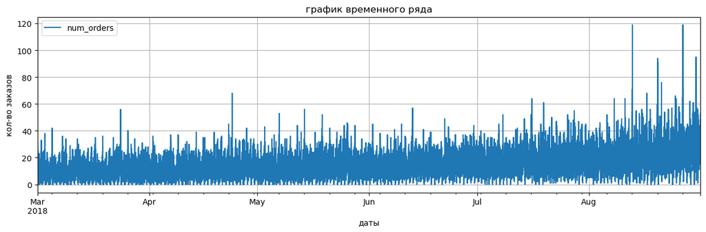

```python
data.plot(figsize = (15,4),
          title = 'график временного ряда',
          xlabel = 'даты',
          ylabel = 'кол-во заказов',
          grid = True);
```

Даты расположили в хронологическом порядке.

В датафрейме представлены данные с марта 2018 по август 2018, всего 26496 наблюдений.

Данные содержат заказы "поминутно", т.е. интервал временного ряда измеряется в минутах.

Так как нам необходимо будет строить прогноз на кол-во заказов в следующий час, давайте изменим интервал временного ряда на часы и посмотрим на его график:

```python
data = data.resample('1H').sum()
```

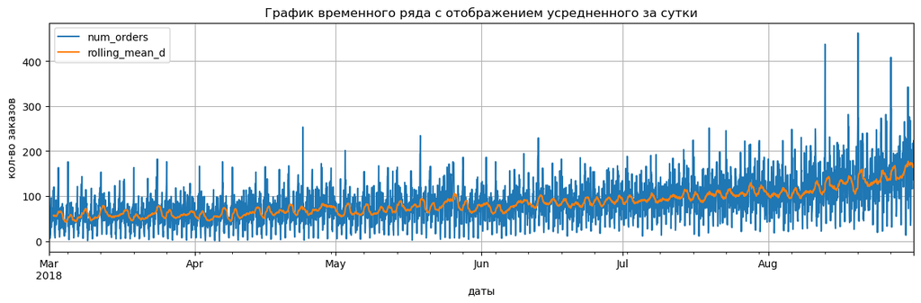

```python
data_new = data.copy()
data_new['rolling_mean_d'] = data_new.rolling(24).mean();
data_new.plot(
    figsize = (15,4),
    title = 'График временного ряда с отображением усредненного за сутки',
    xlabel = 'даты',
    ylabel = 'кол-во заказов',
    grid = True);
```

Также похоже на то, что наш ряд имеет небольшое кол-во выбросов, которые влияют на разброс.

### Шаг 2. Анализ данных.

Среднее кол-во заказов по месяцам:

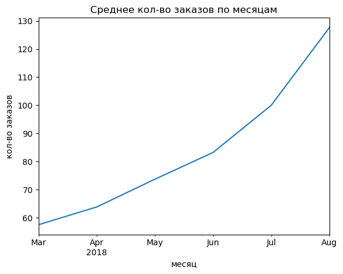

```python
data.resample('1m').mean().plot(
    title = 'Среднее кол-во заказов по месяцам',
    legend = False,
    xlabel = 'месяц',
    ylabel = 'кол-во заказов'
);
```

Заметен рост заказов компании с марта по август. Самый "урожайный" на заказы месяц - август.

Разберем тренды и сезонность:

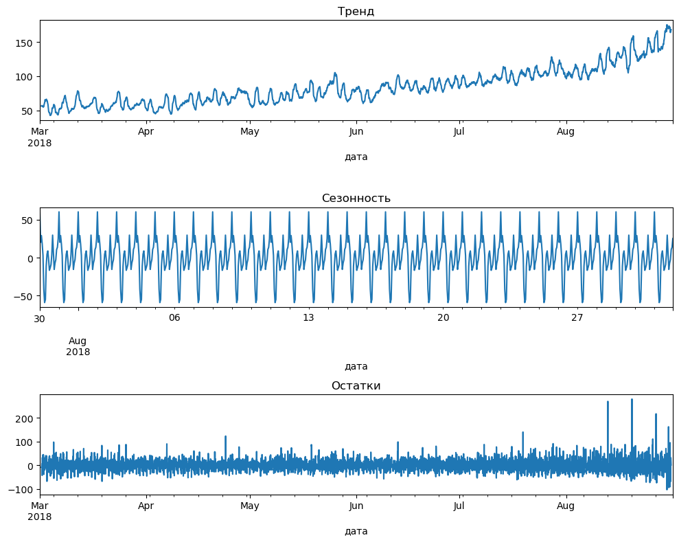

```python
decomposed = seasonal_decompose(data)

plt.figure(figsize=(10, 8))
plt.subplot(311)
decomposed.trend.plot(ax=plt.gca())
plt.title('Тренд')
plt.xlabel('дата')

plt.subplot(312)
decomposed.seasonal['2018-07-30':'2018-08-31'].plot(ax=plt.gca())
plt.title('Сезонность')
plt.xlabel('дата')

plt.subplot(313)
decomposed.resid.plot(ax=plt.gca())
plt.title('Остатки')
plt.xlabel('дата')

plt.tight_layout()
```

Да, как раз виден тренд по месяцам что кол-во заказов в марте низкое, и к августу растет.

В остатках никакой закономерности не видно, похоже на случайные колебания(шум).

Сезонность же похоже с периодом примерно в день, посмотрим поближе:

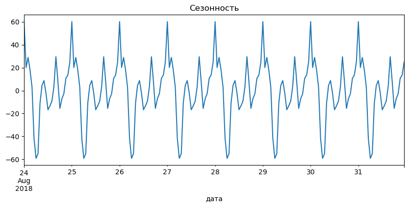

```python
decomposed.seasonal['2018-08-24':'2018-08-31'].plot(ax=plt.gca(),figsize=(10, 4))
plt.title('Сезонность');
plt.xlabel('дата');
```

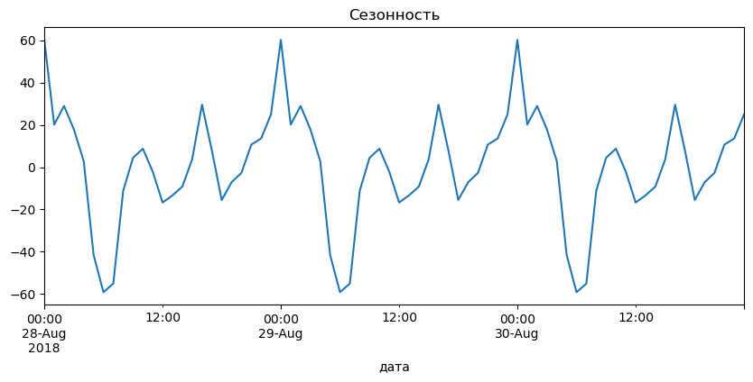

```python
decomposed.seasonal['2018-08-28':'2018-08-30'].plot( figsize = (10,4))
plt.title('Сезонность');
plt.xlabel('дата');
```

Да, наблюдается "сезонность" с периодом в день. Больше всего заказов в 00:00 и провал в 6:00.

Посмотрим еще тренд и сезонность по неделям, для этого воспользуемся ресемплингом по суткам:

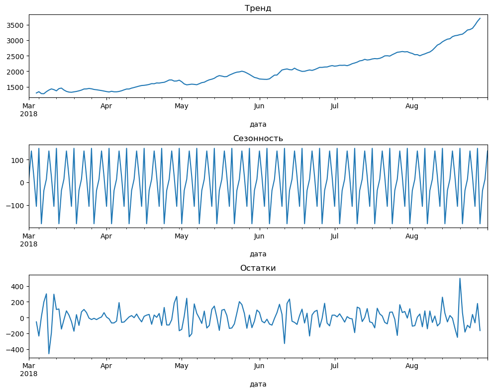

```python
data_new = data.copy()

data_new = data_new.resample('1D').sum()

decomposed = seasonal_decompose(data_new)

plt.figure(figsize=(10, 8))
plt.subplot(311)
decomposed.trend.plot(ax=plt.gca())
plt.title('Тренд')
plt.xlabel('дата')

plt.subplot(312)
decomposed.seasonal.plot(ax=plt.gca())
plt.title('Сезонность')
plt.xlabel('дата')

plt.subplot(313)
decomposed.resid.plot(ax=plt.gca())
plt.title('Остатки')
plt.xlabel('дата')

plt.tight_layout()
```

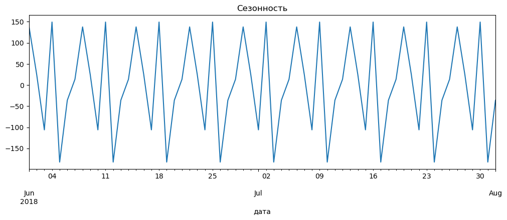

```python
decomposed.seasonal['2018-06-01':'2018-08-01'].plot(ax=plt.gca(), figsize=(12, 4))
plt.title('Сезонность');
plt.xlabel('дата');
```

Заметна также недельная сезонность, каждый раз в будни больший всплеск заказов.

Посмотрим на примере августа характеристики наших данных по кол-ву заказов:

```python
data['2018-08-01':'2018-08-31'].describe()
```

|  | num_orders |
| --- | --- |
| count | 744.000000 |
| mean | 127.651882 |
| std | 56.242228 |
| min | 13.000000 |
| 25% | 91.000000 |
| 50% | 122.000000 |
| 75% | 160.000000 |
| max | 462.000000 |

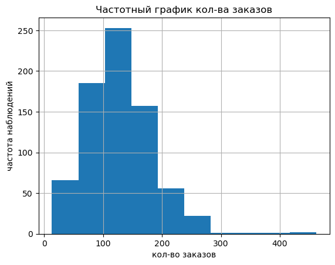

```python
data['2018-08-01':'2018-08-31'].hist();
plt.title('Частотный график кол-ва заказов');
plt.xlabel('кол-во заказов');
plt.ylabel('частота наблюдений');
```

Среднее кол-во заказов за час в августе - 128. Ряд имеет выбросы, и немалое среднее отклонение - 56 заказов.

Вроде наш ряд выглядит стационарным, но тренд достаточно сильно растущий (растет среднее значение).

Для более точной оценки стационарности применим тест Дики-Фуллера (Dickey-Fuller test).

- Нулевая гипотеза предполагает, что процесс нестационарный
- Альтернативная гипотеза предполагает, что процесс стационарный

Используем пороговое значение, равное 5% (0.05).

```python
# уровень статистической значимости
alpha = 0.05

#Применяем тест
adf_test = adfuller(data)

# выведем p-value
print('p-value = ', round(adf_test[1],3))

if (adf_test[1] < alpha):
    print('Отвергаем нулевую гипотезу, ряд стационарен','\n')
else:
    print('Не отвергаем нулевую гипотезу, ряд нестационарен','\n')
```

```
p-value =  0.029
Отвергаем нулевую гипотезу, ряд стационарен
```

Наш временной ряд стационарен.

Посмотрим еще на график автокорреляции данных PACF:

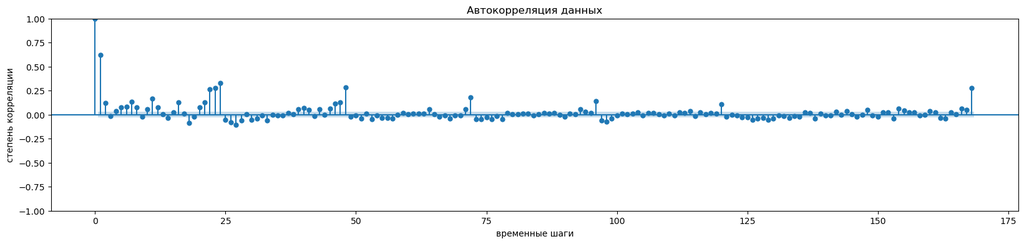

```python
#fig,ax = plt.figure(figsize=(10, 10))
fig, ax = plt.subplots(nrows=1, ncols=1, figsize=(20, 4))
plot_pacf(data, method='ywm', title = 'Автокорреляция данных', lags=168, ax =ax);
plt.xlabel('временные шаги');
#plt.figure(figsize=(15, 5));
plt.ylabel('степень корреляции');
```

Очевидно, что на этом графике присутствует значительная автокорреляция.

Существует сильная положительная автокорреляция с запаздыванием на 1 шаг: высокое значение сейчас означает, что вы с большой вероятностью увидите высокое значение на следующем шаге.

Переводя на "бизнесовый язык": Высокое кол-во заказов сейчас означает, что с большой вероятностью мы увидим большое кол-во заказов на следующий час.

Также можно заметить что значимая автокорреляция будет повторяться каждые сутки. (Выше мы также наблюдали сезонность суточную).

### Шаг 3. Построение и обучение моделей.

Перед нами задача машинного обучения с учителем - будем пробовать регрессионные модели (LinearRegression, xgboost). В качестве метрики будем использовать RMSE.

В качестве календарных признаков для будущей модели выделим часы и день недели.

Учитывая ту сезонность, которую мы видели выше, наше окно скользящего среднего должно быть скорее всего 24 часа или кратное этому. Ну а подходящее значение вычислим пустем подбора, как и лаг.

```python
def make_features(data, max_lag, rolling_mean_size):
    """
    Функция для создания признаков.
    На вход принимает data- датафрейм,
    rolling_mean_size - интервал в котором будет происходить усреднение,
    max_lag - кол-во "отставаний", которое будем использовать для признаков
    """
    #Добавляем календарные признаки
    data['dayofweek'] = data.index.dayofweek
    data['hour'] = data.index.hour

    #Добавляем признаки с отстающими значениями
    for lag in range(1, max_lag + 1):
        data['lag_{}'.format(lag)] = data['num_orders'].shift(lag)

    #Добавялем признак скользящего среднего
    data['rolling_mean'] = data['num_orders'].shift(1).rolling(rolling_mean_size).mean()
```

```python
def split(data, test_size):
    """
    Функция для разделения на обучающую и тестовую выборки
    На вход принимает датафрейм и процент тестовой выборки
    """
    #Разбиваем на обучающую и тестовую выборку
    train, test = train_test_split(data, shuffle=False, test_size=test_size)
    train = train.dropna()

    #Обозначаем общие и целевой признаки
    target_train = train['num_orders']
    target_test = test['num_orders']
    features_train = train.drop(['num_orders'], axis = 1)
    features_test = test.drop(['num_orders'], axis = 1)

    return (features_train, target_train, features_test, target_test)
```

**Попробуем модель линейной регрессии:**

```python
#перебираемые значения лагов
lags=[0,1,2,12,24,48]

#перебираемые значения окон
window_sizes=[24,48,72,168]

best_params_lr = {'lag':0, 'window_size':0, 'best_rmse':999999}

for lag in lags:
    for window_size in window_sizes:

        data_new = data.copy()

        #Создаем признаки и делим датасет на выборки
        make_features(data_new, lag, window_size)
        features_train, target_train, features_test, target_test = split(data_new, 0.1)

        #Создаем и обучаем модель
        cur_model = LinearRegression()
        cur_model.fit(features_train,target_train)

        #Делаем предсказание на обучающей выборке и получаем качество
        predicted_train = cur_model.predict(features_train)
        cur_rmse = -cross_val_score(
            cur_model,
            features_train,
            target_train,
            scoring='neg_root_mean_squared_error',
            cv=TimeSeriesSplit(n_splits=5)).mean()

        #Принтуем итоги каждого шага
        print ('lag= ',lag, 'window_size = ',window_size)
        print ('cur_rmse = ', round(cur_rmse,2),'\n')

        #Сохраняем наилучшие результаты
        if (cur_rmse < best_params_lr['best_rmse']):
            best_params_lr['lag']=lag
            best_params_lr['window_size']= window_size
            best_params_lr['best_rmse'] = round(cur_rmse,2)
            best_model_lr = cur_model
            best_data_lr = data_new

print ('Параметры и rmse лучшей модели',best_params_lr)
```

```
lag=  0 window_size =  24
cur_rmse =  35.48

lag=  0 window_size =  48
cur_rmse =  35.52

lag=  0 window_size =  72
cur_rmse =  35.33

lag=  0 window_size =  168
cur_rmse =  35.72

lag=  1 window_size =  24
cur_rmse =  31.79

lag=  1 window_size =  48
cur_rmse =  31.74

lag=  1 window_size =  72
cur_rmse =  31.68

lag=  1 window_size =  168
cur_rmse =  31.86

lag=  2 window_size =  24
cur_rmse =  31.81

lag=  2 window_size =  48
cur_rmse =  31.76

lag=  2 window_size =  72
cur_rmse =  31.7

lag=  2 window_size =  168
cur_rmse =  31.85

lag=  12 window_size =  24
cur_rmse =  31.61

lag=  12 window_size =  48
```

[output cut: 18 more lines]

```
cur_rmse =  27.07

lag=  48 window_size =  24
cur_rmse =  24.73

lag=  48 window_size =  48
cur_rmse =  24.73

lag=  48 window_size =  72
cur_rmse =  24.8

lag=  48 window_size =  168
cur_rmse =  24.75

Параметры и rmse лучшей модели {'lag': 48, 'window_size': 48, 'best_rmse': 24.73}
```

В результате получаем лучшее значение метрики RMSE = 24.73 при следующих параметрах {'lag': 48, 'window_size': 48}

**Попробуем регрессионную модель xgboost:**

```python
#перебираемые значения лагов
lags=[0,1,2,12,24,48]

#перебираемые значения окон
window_sizes=[24,48,72,168]

best_params_xgb = {'lag':0, 'window_size':0, 'best_rmse':999999}
data_new = data.copy()

for lag in lags:
    for window_size in window_sizes:

        #Создаем признаки и делим датасет на выборки
        make_features(data_new, lag, window_size)
        features_train, target_train, features_test, target_test = split(data_new, 0.1)

        #Создаем и обучаем модель
        cur_model = xgb.XGBRegressor()
        cur_model.fit(features_train,target_train)

        #Делаем предсказание на обучающей выборке и получаем качество
        predicted_train = cur_model.predict(features_train)
        cur_rmse = -cross_val_score(
            cur_model,
            features_train,
            target_train,
            scoring='neg_root_mean_squared_error',
            cv=TimeSeriesSplit(n_splits=5)).mean()

        #Принтуем итоги каждого шага
        print ('lag= ',lag, 'window_size = ',window_size)
        print ('cur_rmse = ', round(cur_rmse,2),'\n')

        #Сохраняем наилучшие результаты
        if (cur_rmse < best_params_xgb['best_rmse']):
            best_params_xgb['lag']=lag
            best_params_xgb['window_size']= window_size
            best_params_xgb['best_rmse'] = round(cur_rmse,2)
            best_model_xgb = cur_model
            best_data_xgb = data_new

print ('Параметры и rmse лучшей модели', best_params_xgb)
```

```
lag=  0 window_size =  24
cur_rmse =  26.86

lag=  0 window_size =  48
cur_rmse =  27.32

lag=  0 window_size =  72
cur_rmse =  28.59

lag=  0 window_size =  168
cur_rmse =  30.27

lag=  1 window_size =  24
cur_rmse =  26.99

lag=  1 window_size =  48
cur_rmse =  26.61

lag=  1 window_size =  72
cur_rmse =  28.15

lag=  1 window_size =  168
cur_rmse =  30.04

lag=  2 window_size =  24
cur_rmse =  26.92

lag=  2 window_size =  48
cur_rmse =  26.91

lag=  2 window_size =  72
cur_rmse =  28.17

lag=  2 window_size =  168
cur_rmse =  30.02

lag=  12 window_size =  24
cur_rmse =  26.31

lag=  12 window_size =  48
```

[output cut: 18 more lines]

```
cur_rmse =  26.89

lag=  48 window_size =  24
cur_rmse =  25.44

lag=  48 window_size =  48
cur_rmse =  25.36

lag=  48 window_size =  72
cur_rmse =  25.35

lag=  48 window_size =  168
cur_rmse =  25.49

Параметры и rmse лучшей модели {'lag': 48, 'window_size': 72, 'best_rmse': 25.35}
```

Было получено лучшее значение метрики RMSE = 25.35 при следующих параметрах лаг = 48, окно = 72.

Модель линейной регрессии показала качество получше, ее и возьмем в тестирование.

### Шаг 4. Тестирование выбранной модели

Воспроизводим деление на выборки:

```python
features_train, target_train, features_test, target_test = split(best_data_lr, 0.1)
```

```python
#Делаем предсказание на тестовой выборке
predicted_test = best_model_lr.predict(features_test)
rmse_test = round(mean_squared_error(target_test, predicted_test, squared=False),2)

print ('Качество на тестовой выборке = ', rmse_test)
```

```
Качество на тестовой выборке =  41.84
```

**Проверим модель на адекватность:**

Будем предсказывать новое значение ряда x(t) предыдущим x(t-1). У нас в датафреме поделенном на обучающую и тестовую выборку как раз есть отстающие на один шаг значения, воспользуемся ими

```python
direct_pred_feature_lag_test = features_test['lag_1']

#Смотрим качество
direct_pred_rmse = round(mean_squared_error(
    target_test,
    direct_pred_feature_lag_test,
    squared=False
),2)

print ('Качество предсказания = ', direct_pred_rmse)
```

```
Качество предсказания =  58.86
```

Метрика RMSE у нашей модели существенно лучше чем у прогноза предыдущим значением, что говорит об ее адекватности.

**Важность признаков при моделировании:**

Посмотрим какие факторы важны при прогнозировании количества заказов (топ-5):

```python
#получим важность признаков
shap_values = shap.TreeExplainer(
    best_model_xgb).shap_values(features_train)
```

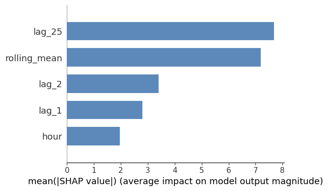

```python
#построим график
shap.summary_plot(
    shap_values,
    features_train,
    plot_type="bar",
    plot_size = (6,4),
    color ='#5d89ba',
    max_display = 5)
```

### Шаг 5. Общий вывод.

#### Цели исследования

Необходимо построить модель для прогнозирования количества заказов такси на следующий час. В распоряжении есть исторические данные о заказах такси в аэропортах.

В качестве метрики использовать RMSE, ее значение на тестовой выборке должно быть не больше 48.

#### Полученные данные были изучены и прошли следующую предобработку:

- Даты расположили в хронологическом порядке.
- В датафрейме представлены данные с марта 2018 по август 2018, всего 26496 наблюдений.
- Данные содержат заказы "поминутно", т.е. интервал временного ряда измеряется в минутах. Так как нам необходимо строить прогноз на кол-во заказов в следующий час, интервал временного ряда был изменен на часы. График временного ряда:

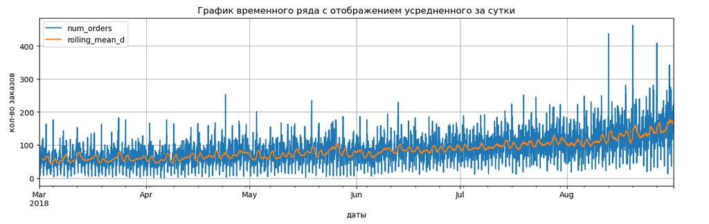

- Также похоже на то, что наш ряд имеет небольшое кол-во выбросов, которые влияют на разброс.

#### Анализ данных:

- Было проанализировано среднее количество заказов по месяцам (график представлен ниже). Заметен рост заказов компании с марта по август. Самый "урожайный" на заказы месяц - август.

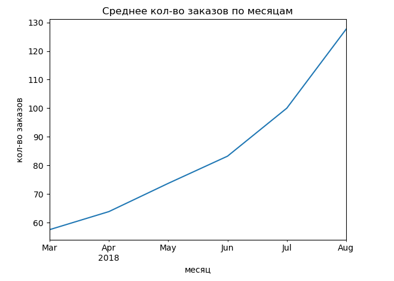

- Были проанализированы тренды и сезонность (графики представлены ниже) Как раз виден тренд по месяцам что кол-во заказов в марте низкое, и к августу растет.

В остатках никакой закономерности не видно, похоже на случайные колебания(шум).

Сезонность наблюдается с периодом в день. Больше всего заказов в 00:00 и провал в 6:00.

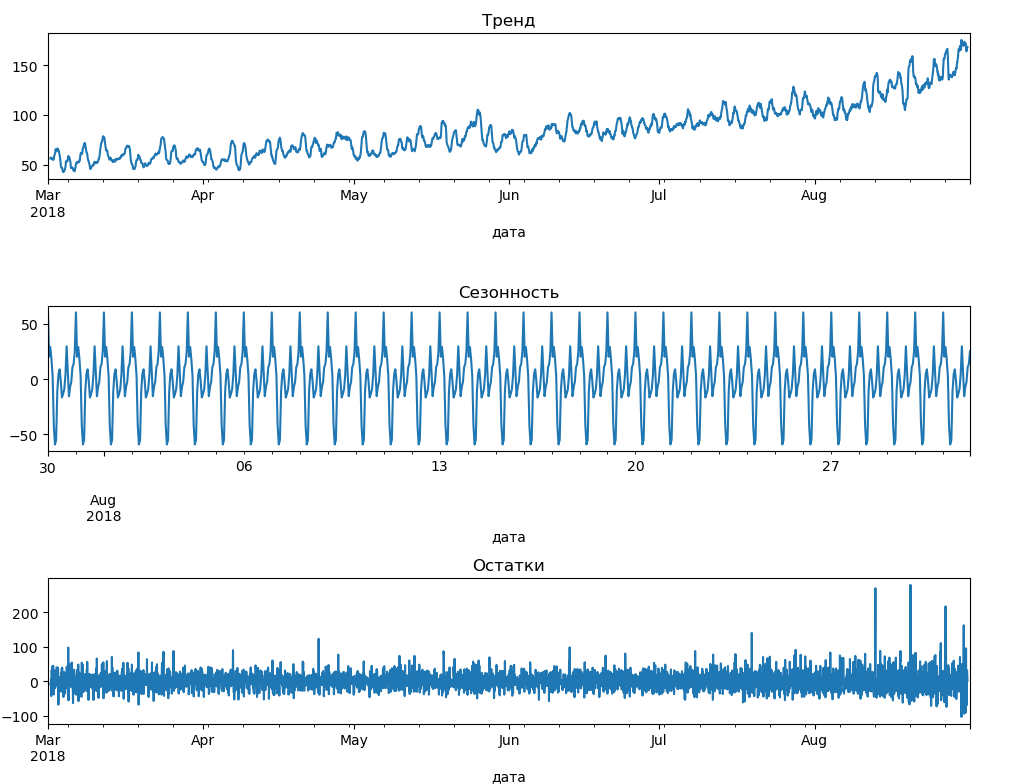

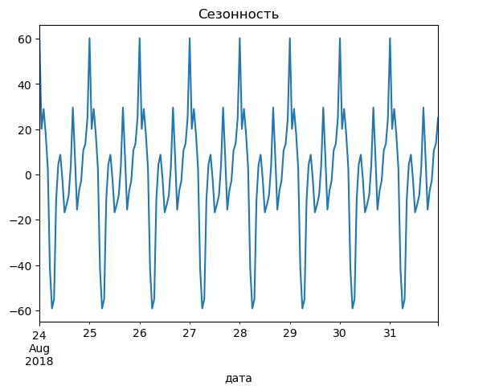

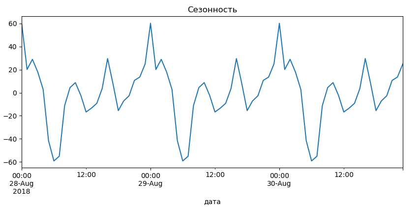

Также при ресемплинге данных по суткам, можно заметить недельную сезонность. Каждый раз в будни больший всплеск заказов

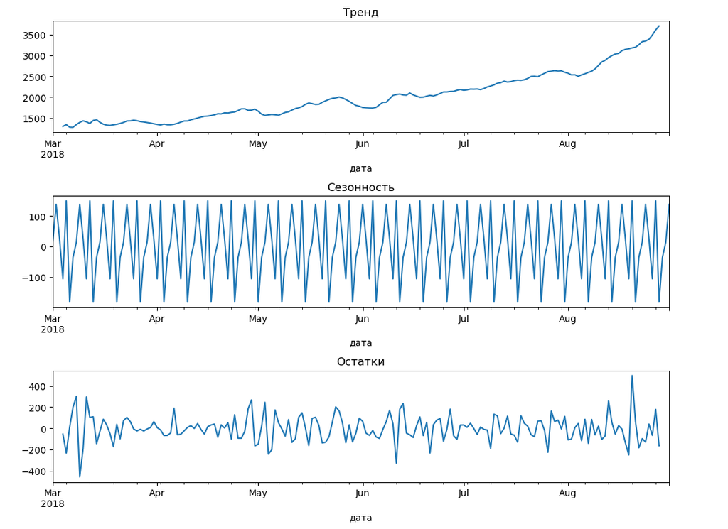

- На примере августа были проанализированы характеристики наших данных по кол-ву заказов:

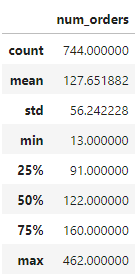

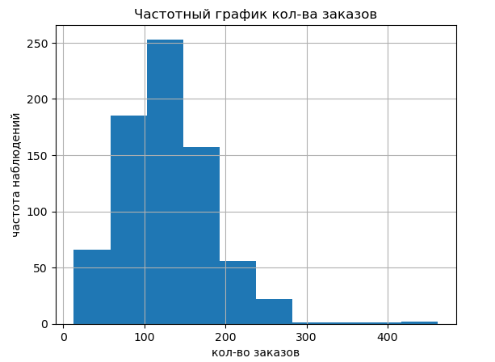

Среднее кол-во заказов за час в августе - 128. Ряд имеет выбросы, и немалое среднее отклонение - 56 заказов.

- Вроде наш ряд выглядит стационарным, но тренд достаточно сильно растущий (растет среднее значение). Для более точной оценки стационарности был применен тест Дики-Фуллера (Dickey-Fuller test).
  - Нулевая гипотеза предполагает, что процесс нестационарный
  - Альтернативная гипотеза предполагает, что процесс стационарный

Используем пороговое значение, равное 5% (0.05).

- Был проанализирован график автокорреляции данных PACF (представлен ниже). Очевидно, что на этом графике присутствует значительная автокорреляция.

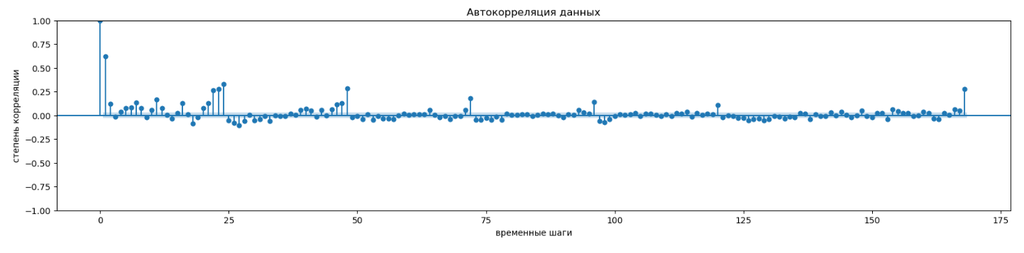

Существует сильная положительная автокорреляция с запаздыванием на 1 шаг: высокое значение сейчас означает, что вы с большой вероятностью увидите высокое значение на следующем шаге.

Переводя на "бизнесовый язык": Высокое кол-во заказов сейчас означает, что с большой вероятностью мы увидим большое кол-во заказов на следующий час.

Также можно заметить что значимая автокорреляция будет повторяться каждые сутки. (Выше мы также наблюдали сезонность суточную).

#### Построение и обучение моделей:

Перед нами задача машинного обучения с учителем - были опробованы регрессионные модели (LinearRegression, xgboost). В качестве метрики использовалась метрика RMSE.

В качестве календарных признаков для будущей модели выделим часы и день недели.

Учитывая ту сезонность, которую мы видели выше, наше окно скользящего среднего должно быть скорее всего 24 часа или кратное этому. Ну а подходящее значение уже вычислялось пустем подбора, как и лаг для каждой модели, и результаты будут описаны ниже.

Перебираемые значения лагов: [0,1,2,12,24,48]

Перебираемые значения окон: [24,48,72,168]

**Модель линейной регрессии:**

В результате было получено лучшее значение метрики RMSE = 24.73 при следующих параметрах лаг = 48, окно = 48

**Модель xgboost:**

Было получено лучшее значение метрики RMSE = 25.35 при следующих параметрах лаг = 48, окно = 72.

#### Тестирование модели и проверка адекватности:

Для проверки на адекватность использовалось предсказание нового значения ряда x(t) предыдущим x(t-1).

По результатам тестирования и проверки на адекватность были получены следующие результаты:

```
* Для модели линейной регрессии была получена RMSE = 41.84 на тестовой выборке.
* Для предсказания предыдущим значением метрика RMSE =  58.86.
```

На тестовых данных модель линейной регрессии показала хорошее качество.

Метрика RMSE у нашей модели существенно лучше чем у прогноза предыдущим значением, что говорит об ее адекватности.

- Была проанализирована важность признаков при моделировании:

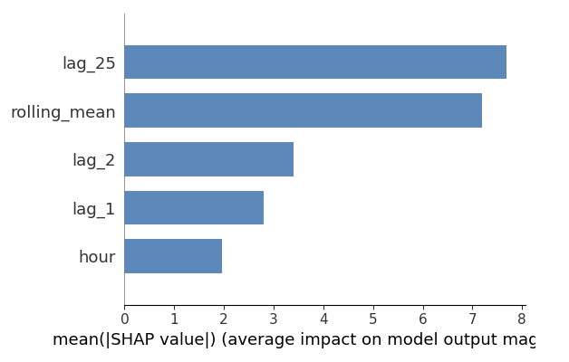

### Вывод и рекомендации:

По итогу работы можно рекомендовать модель линейной регрессии, с указанными выше характеристиками для предсказания количества заказов такси в следующий час.

Мы надеемся, что данная модель поможет в оптимизации обсуживания поступающих заказов такси, и готовы провести дополнительное исследование, если текущий результат недостаточен.